# Analysis of Budweiser Beer and Brewery Data

## Introduction

We want to analyze the distribution of manufacturing centers of Budweiser beer around the US, and additionally track features and attributes of the different beers produced. We first set up our workspace, by loading requisite libraries and reading in the data.

```r
library(data.table)
library(ggplot2)
beers <- fread('~/smu_msds_6306_casestudy1/data/Beers.csv')
breweries <- fread('~/smu_msds_6306_casestudy1/data/Breweries.csv')
```

## Questions of Interest

The first question of interest is the number of breweries by state. Looking at the geographical distribution of our breweries can give us a sense of which regionals benefit the most from our supply chain.

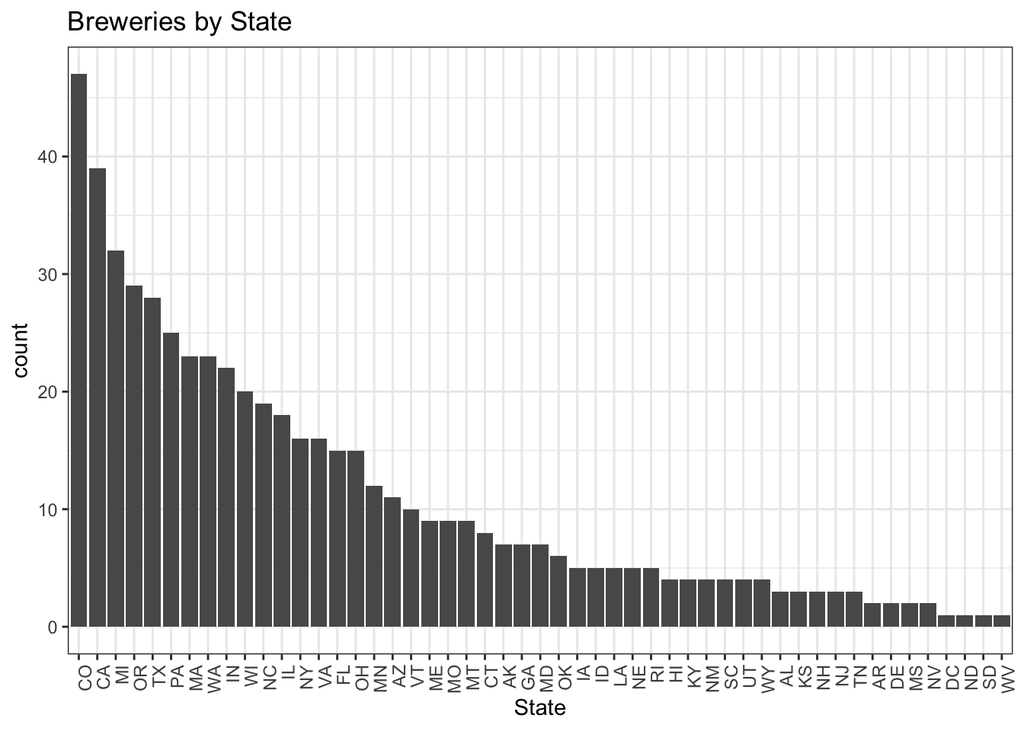

```r
breweries[, state_count := .N, by='State']
plot(
  ggplot(data=breweries, aes(x=reorder(State, -state_count))) +
    geom_bar() +
    theme_bw() +
    xlab("State") +
    theme(axis.text.x = element_text(angle=90, hjust=1)) +
    ggtitle("Breweries by State")
)
```

It’s clear California, Michigan, and Colorado have the most breweries. Some states that may benefit from additional manufacturing may be New York, Tennessee, and Nevada - judging by population and relative low number of breweries.

Next, we want to see which beers are produced in which breweries.

```r
# merge
master <- merge(beers, breweries, by.x='Brewery_id', by.y='Brew_ID')
setnames(master, c('Name.x', 'Name.y'), c('Beer_name', 'brewery'))

head(master[, list(Beer_name, brewery, State)], 6)
```

```
##        Beer_name           brewery State
## 1:  Get Together NorthGate Brewing    MN
## 2: Maggie's Leap NorthGate Brewing    MN
## 3:    Wall's End NorthGate Brewing    MN
## 4:       Pumpion NorthGate Brewing    MN
## 5:    Stronghold NorthGate Brewing    MN
## 6:   Parapet ESB NorthGate Brewing    MN
```

One possible weak point in our analysis is the number of missing values. Below, we show the number of missing values in each column.

```r
nas <- lapply(names(master), function(x) {
  test <- unlist(master[, get(x)])
  test <- test[is.na(test)]
  return(length(test))
})

na_df <- data.table(
  col = names(master),
  nas = nas,
  pct_nas = lapply(nas, function(x) x/nrow(master))
)
na_df
```

```
##             col  nas    pct_nas
##  1:  Brewery_id    0          0
##  2:   Beer_name    0          0
##  3:     Beer_ID    0          0
##  4:         ABV   62 0.02572614
##  5:         IBU 1005  0.4170124
##  6:       Style    0          0
##  7:      Ounces    0          0
##  8:     brewery    0          0
##  9:        City    0          0
## 10:       State    0          0
## 11: state_count    0          0
```

We see that information is complete on all columns besides the alcohol by volume and the bitterness of each beer. A logical assumption to a missing ABV entry may be to assume that beer is non-alcoholic; if that’s the case, then we can simply impute 0 for the missing values. However, spot checks on those missing values did not reveal those beers to be non-alcoholic. We will then proceed to perform some mean imputation.

Ideally we could do this by brewery, on both ABV and IBU. However, it appears that many breweries fail to report this data at all.

```r
# Missing alcohol by volume reporting
head(unique(master[, if(!any(!is.na(ABV))) .SD, by='brewery']$brewery), 10)
```

```
##  [1] "Blue Owl Brewing"               "Keweenaw Brewing Company"
##  [3] "Fort Pitt Brewing Company"      "Iron Hill Brewery & Restaurant"
##  [5] "Brindle Dog Brewing Company"    "The Manhattan Brewing Company"
##  [7] "Dock Street Brewery"            "Cans Bar and Canteen"
##  [9] "Spilker Ales"                   "Dolores River Brewery"
```

```r
# Missing bitterness reporting
head(unique(master[, if(!any(!is.na(IBU))) .SD, by='brewery']$brewery), 10)
```

```
##  [1] "COAST Brewing Company"       "The Mitten Brewing Company"
##  [3] "Brewery Vivant"              "Brew Link Brewing"
##  [5] "James Page Brewing Company"  "Anchor Brewing Company"
##  [7] "Rising Tide Brewing Company" "White Birch Brewing"
##  [9] "Pipeworks Brewing Company"   "Flesk Brewing Company"
```

```r
master[, `:=`(ABV = replace(ABV, is.na(ABV), mean(ABV, na.rm=TRUE)),
              IBU = replace(IBU, is.na(IBU), as.integer(round(mean(IBU, na.rm=TRUE))))),
       by='State']
```

We still see that no breweries in South Dakota report any bitterness measurements, but there are only 7 beers produced in South Dakota, a small number relative to the size of our dataset. We will carry on ignoring those 7 missing values.

```r
nas <- lapply(names(master), function(x) {
  test <- unlist(master[, get(x)])
  test <- test[is.na(test)]
  return(length(test))
})

na_df <- data.table(
  col = names(master),
  nas = nas
)
na_df
```

```
##             col nas
##  1:  Brewery_id   0
##  2:   Beer_name   0
##  3:     Beer_ID   0
##  4:         ABV   0
##  5:         IBU   7
##  6:       Style   0
##  7:      Ounces   0
##  8:     brewery   0
##  9:        City   0
## 10:       State   0
## 11: state_count   0
```

Additionally, we discovered 5 beers without a style listed. For the purposes of this analysis we will group these beers with the “Other” grouping.

```r
master[Style=="", Style := "Other"]
```

After imputation, we now want to see the median alcohol by volume and the median bitterness of beers produced in each state.

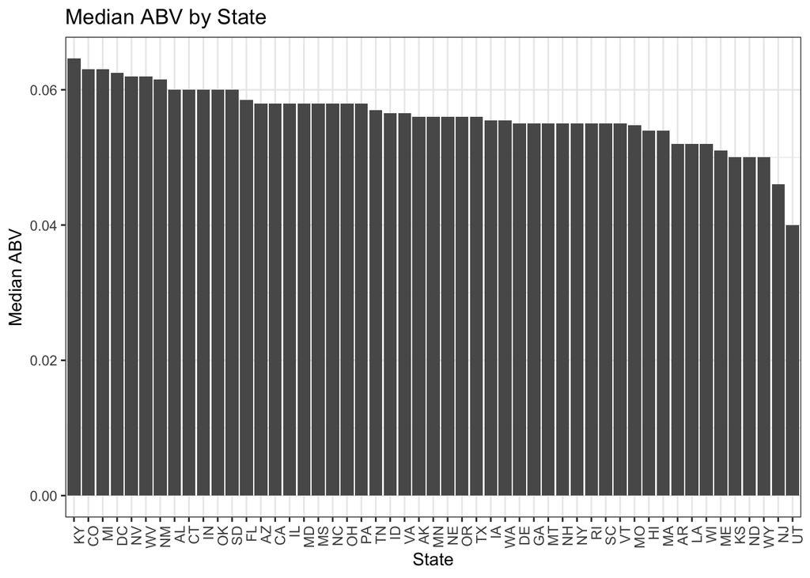

```r
meds <- master[, list(med_alc = median(ABV, na.rm=T), med_bit = median(IBU, na.rm=T)), by='State']

# ABV by state
plot(
  ggplot(data=meds, aes(x=reorder(State, -med_alc), y=med_alc)) +
    theme_bw() +
    ggtitle("Median ABV by State") +
    geom_bar(stat='identity', position='dodge') +
    xlab("State") +
    ylab("Median ABV") +
    theme(axis.text.x = element_text(angle=90, hjust=1))
)
```

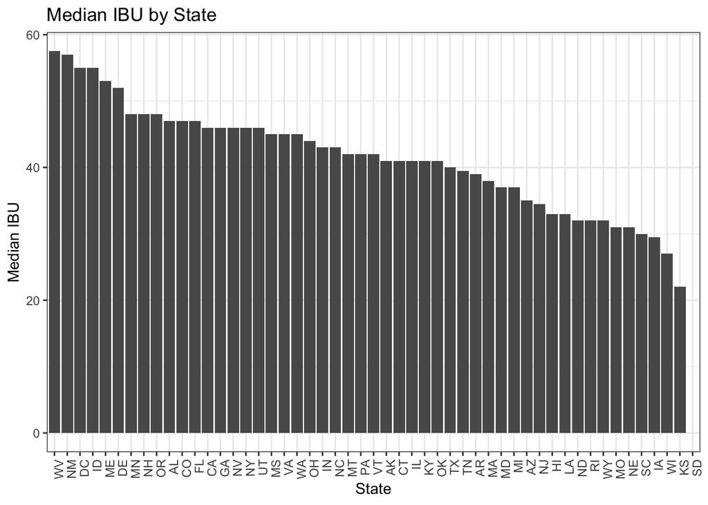

```r
# IBU by state
plot(
  ggplot(data=meds, aes(x=reorder(State, -med_bit), y=med_bit)) +
    theme_bw() +
    ggtitle("Median IBU by State") +
    geom_bar(stat='identity', position='dodge') +
    xlab("State") +
    ylab("Median IBU") +
    theme(axis.text.x = element_text(angle=90, hjust=1))
)
```

From this, we see that Kentucky, Colorado, and Michigan produce the most alcoholic beers on average, while West Virginia, New Mexico, and Washington DC produce the bitterest beers on average.

Summary statistics are always helpful for quick analysis. Across the US, we have a summary for ABV:

```r
summary(master$ABV)
```

```
##    Min. 1st Qu.  Median    Mean 3rd Qu.    Max.
##  0.0010  0.0500  0.0570  0.0598  0.0670  0.1280
```

We see a mean ABV of about 5.98%, and a median of 5.7%, suggesting most beers are less alcoholic than the mean - the ABV 10%+ beers may be skewing the average.

Another question of interest may be whether high-alcohol beers tend to be more bitter. We will look at a scatterplot to see if anything is revealed.

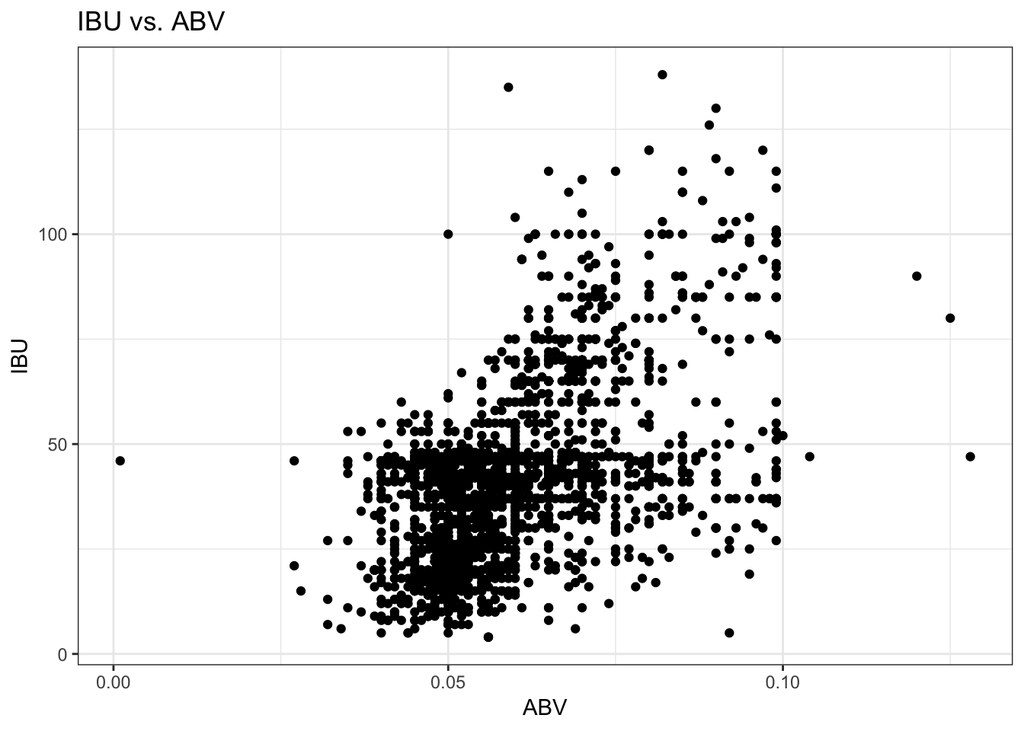

```r
plot(
  ggplot(data=master, aes(x=ABV, y=IBU)) +
    theme_bw()+
    geom_point() +
    ggtitle("IBU vs. ABV")
)
```

We do see the beginnings of what may be a linear relationship there. On average, it looks like highly alcoholic beers are correlated with a higher IBU rating. We will test this with a simple linear regression.

```r
lin_reg <- lm(formula = IBU~ABV, data=master)
summary(lin_reg)
```

```
##
## Call:
## lm(formula = IBU ~ ABV, data = master)
##
## Residuals:
##     Min      1Q  Median      3Q     Max
## -61.966 -12.440  -1.425  11.240  93.342
##
## Coefficients:
##             Estimate Std. Error t value Pr(>|t|)
## (Intercept)   -3.589      1.630  -2.203   0.0277 *
## ABV          766.911     26.589  28.843   <2e-16 ***
## ---
## Signif. codes:  0 '***' 0.001 '**' 0.01 '*' 0.05 '.' 0.1 ' ' 1
##
## Residual standard error: 17.45 on 2401 degrees of freedom
##   (7 observations deleted due to missingness)
## Multiple R-squared:  0.2573, Adjusted R-squared:  0.257
## F-statistic: 831.9 on 1 and 2401 DF,  p-value: < 2.2e-16
```

We see strong evidence at a significance level of .01 that IBU is correlated with ABV. However, the data shows increasing variance in IBU for higher-alcohol beers; a simple linear regression like what we performed in this case is likely biased. If desired, a more robust statistical technique can be used to test this relationship such as a log-transformed linear regression, but the visual evidence is likely satisfactory for this presentation.

## Conclusion

In conclusion, the topics tackled in this document are brewery distribution by state, missing value handling, alcohol and bitterness content by state, and correlation between alcohol and bitterness content. We answered most of these questions using insightful graphical tools.

As for recommendations on paths forward, I leave that up to the bright minds in your company - but I hope the data presented to you and the analysis given will prove useful in guiding you forward. Thank you for listening to my presentation, and best of luck moving forward.